# Exploratory Data Analysis

## 2.2 Do families sink or swim together?

Now that we’ve taken care of splitting passenger name into some new variables, we can take it a step further and make some new family variables. First we’re going to make a **family size** variable based on number of siblings/spouse(s) (maybe someone has more than one spouse?) and number of children/parents.

```r
# Create a family size variable including the passenger themselves 产生一个新的family size变量
full$Fsize <- full$SibSp + full$Parch + 1

# Create a family variable
full$Family <- paste(full$Surname, full$Fsize, sep='_')
```

What does our family size variable look like? To help us understand how it may relate to survival, let’s plot it among the training data.

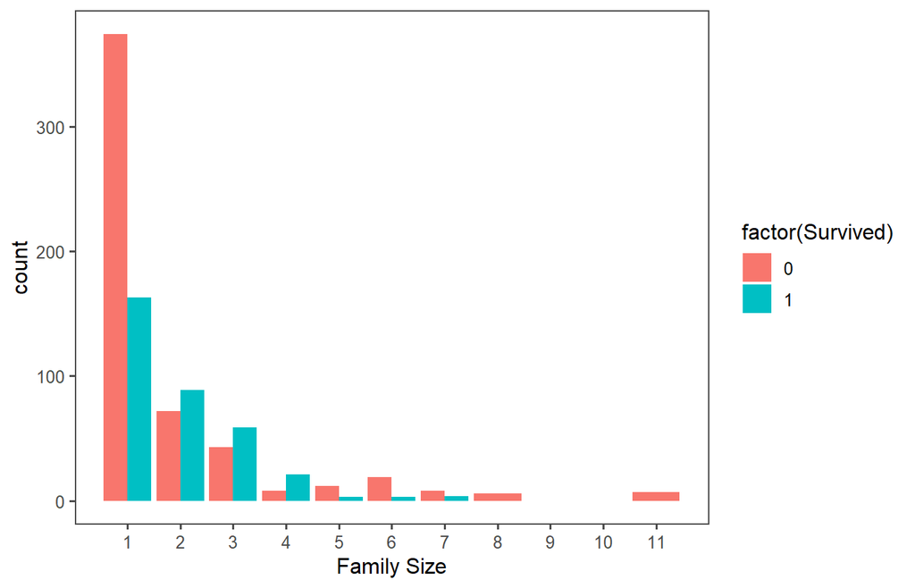

```r
# Use ggplot2 to visualize the relationship between family size & survival
#固定写法， 可以记一些固定的写法
#geom_bar 画直方图
ggplot(full[1:891,], aes(x = Fsize, fill = factor(Survived))) +
  geom_bar(stat='count', position='dodge') +
  scale_x_continuous(breaks=c(1:11)) +
  labs(x = 'Family Size') +
  theme_few()
```

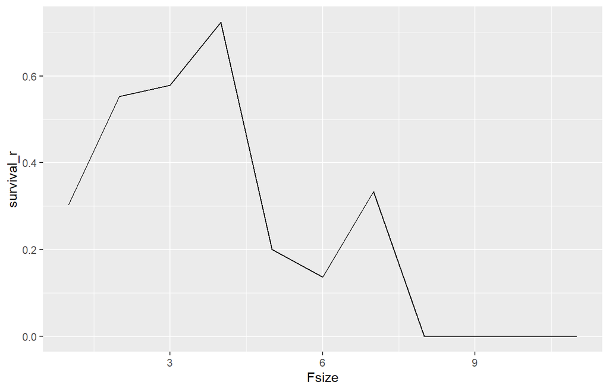

```r
# Survive rate
full[1:891,]%>%
  group_by(Fsize)%>%
  summarise(survival_r=mean(Survived))%>%
  ggplot(aes(x=Fsize,y=survival_r))+
  geom_line() # 画折线图
```

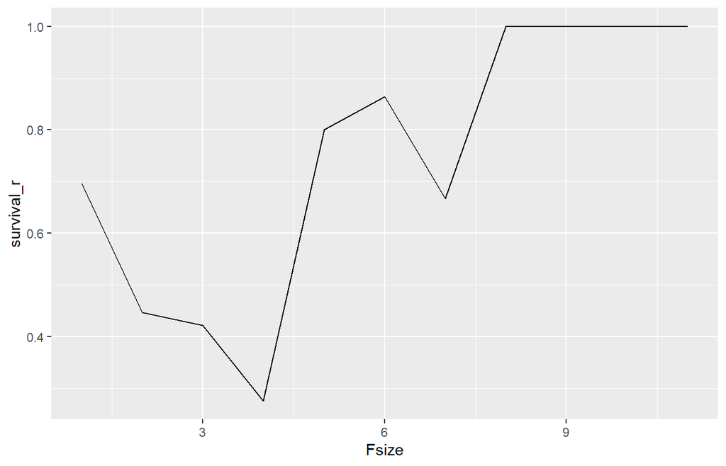

```r
# Death rate
full[1:891,]%>%
  group_by(Fsize)%>%  #分组
  summarise(survival_r= 1 - mean(Survived))%>%
  ggplot(aes(x=Fsize,y=survival_r))+
  geom_line()
```

We can see that there’s a survival penalty to singletons and those with family sizes above 4. Since the number of family members is different, so We can collapse this variable into three levels which will be helpful since there are comparatively fewer large families. Let’s create a **discretized family size** variable.

```r
# Discretize family size 基于family size 产生的新的变量
full$FsizeD[full$Fsize == 1] <- 'singleton'
full$FsizeD[full$Fsize < 5 & full$Fsize > 1] <- 'small'
full$FsizeD[full$Fsize > 4] <- 'large'

table(full$FsizeD, full$Survived)
```

```
##
##               0   1
##   large      52  10
##   singleton 374 163
##   small     123 169
```

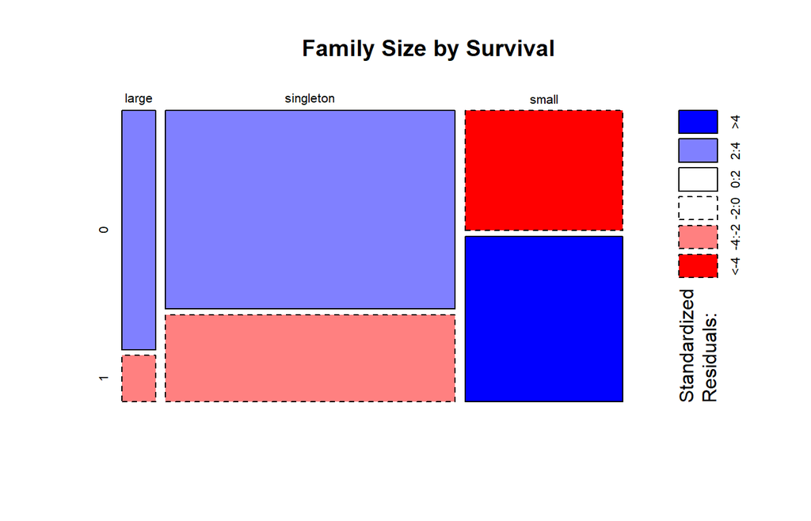

```r
# Show family size by survival using a mosaic plot
mosaicplot(table(full$FsizeD, full$Survived), main='Family Size by Survival', shade=TRUE)
```

The mosaic plot shows that we preserve our rule that there’s a survival penalty among singletons and large families, but a benefit for passengers in small families. I want to do something further with our age variable, but 263 rows have missing age values, so we will have to wait until after we address missingness.

## 2.3 Treat a few more variables

What’s left? There’s probably some potentially useful information in the **passenger cabin** variable including about their **deck**. Let’s take a look.

```r
# This variable appears to have a lot of missing values
full$Cabin[1:28]
```

```
##  [1] ""            "C85"         ""            "C123"        ""
##  [6] ""            "E46"         ""            ""            ""
## [11] "G6"          "C103"        ""            ""            ""
## [16] ""            ""            ""            ""            ""
## [21] ""            "D56"         ""            "A6"          ""
## [26] ""            ""            "C23 C25 C27"
```

```r
# The first character is the deck. For example:
# 直接提取第一个字母,但是这里把每个序号都分散开
#strsplit(full$Cabin[2], NULL)[[1]]

# Create a Deck variable. Get passenger deck A - F:
#full$Deck<-factor(sapply(full$Cabin, function(x) strsplit(x, NULL)[[1]][1]))
#第二种写法
#substr(full$Cabin,1,1)
full<- full%>%
  mutate(Deck = substr(Cabin,1,1)) # creat a new clom
head(full)
```

```
##   PassengerId Survived Pclass
## 1           1        0      3
## 2           2        1      1
## 3           3        1      3
## 4           4        1      1
## 5           5        0      3
## 6           6        0      3
##                                                  Name    Sex Age SibSp
## 1                             Braund, Mr. Owen Harris   male  22     1
## 2 Cumings, Mrs. John Bradley (Florence Briggs Thayer) female  38     1
## 3                              Heikkinen, Miss. Laina female  26     0
## 4        Futrelle, Mrs. Jacques Heath (Lily May Peel) female  35     1
## 5                            Allen, Mr. William Henry   male  35     0
## 6                                    Moran, Mr. James   male  NA     0
##   Parch           Ticket    Fare Cabin Embarked Title   Surname Fsize
## 1     0        A/5 21171  7.2500              S    Mr    Braund     2
## 2     0         PC 17599 71.2833   C85        C   Mrs   Cumings     2
## 3     0 STON/O2. 3101282  7.9250              S  Miss Heikkinen     1
## 4     0           113803 53.1000  C123        S   Mrs  Futrelle     2
## 5     0           373450  8.0500              S    Mr     Allen     1
## 6     0           330877  8.4583              Q    Mr     Moran     1
##        Family    FsizeD Deck
## 1    Braund_2     small
## 2   Cumings_2     small    C
## 3 Heikkinen_1 singleton
## 4  Futrelle_2     small    C
## 5     Allen_1 singleton
## 6     Moran_1 singleton
```

## 2.4 Deck survival rate

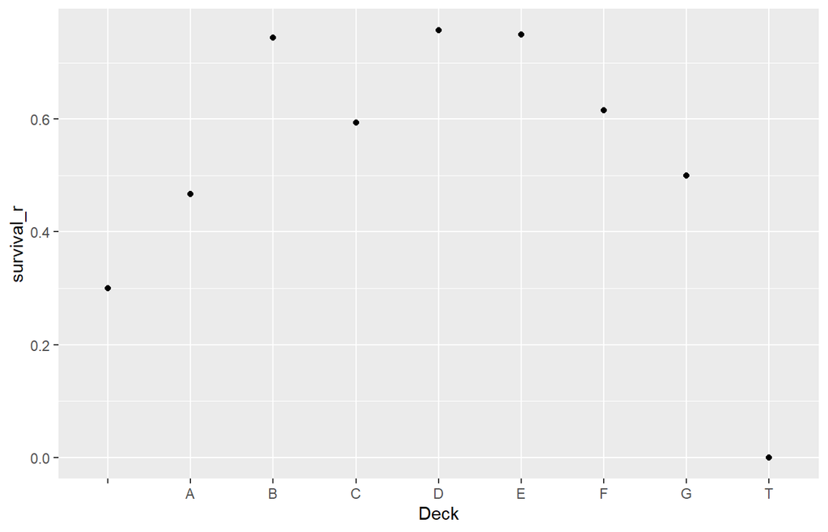

```r
full[1:891,]%>%
  group_by(Deck)%>%
  summarise(survival_r=mean(Survived))%>%
  ggplot(aes(x=Deck,y=survival_r))+
  geom_point() # 画折线图
```

## 2.5 survival rate

There’s more that likely could be done here including looking into cabins with multiple rooms listed (e.g., row 28: “C23 C25 C27”), but given the sparseness of the column we’ll stop here.

# 3 Missingness